# Prediction of Patient Status using Voice Measurements

Vaibhav Gokhale

September 14, 2017

## INTRODUCTION

The Parkinson’s disease (PD) is a type of neurological disease. Many neurological diseases affect phonation of patients, and voice can be a valuable aid in the diagnosis of neurological disease. In Parkinson’s disease, voice disorders affect approximately 45% of patients. In this clinical research case study, the aim is to examine whether by solely using vocal measurements, PD patients can be discriminated from healthy people.

Data Source : https://archive.ics.uci.edu/ml/datasets/parkinsons

## APPROACH

This is a binary classification problem.  
The two objectives of the study are: 1. To examine the data mining methods that produce least type I and type II errors. 2. To find out voice measurements which would significantly contribute in distinguishing PD patients from healthy people.  
*Data Description*  
The data consists of voice measurements from 31 people, 23 with Parkinson’s disease (PD). Each column in the table is a particular voice measure, and each row corresponds one of 195 voice recording from these individuals (“name” column). The main aim of the data is to discriminate healthy people from those with PD, according to “status” column which is set to 0 for healthy and 1 for PD.

## DATA PREPROCESSING

Load the required libraries.

```r
library(caret)
library(MASS)
library(glmnet)
library(DMwR)
library(reshape2)
library(ggplot2)
library(ROCR)
```

Clear the environment variables and import the data

```r
PD_data <- read.csv("parkinsons_data.csv",header = T)
str(PD_data)
```

```
## 'data.frame':    195 obs. of  23 variables:
##  $ MDVP.Fo.Hz.     : num  120 122 117 117 116 ...
##  $ MDVP.Fhi.Hz.    : num  157 149 131 138 142 ...
##  $ MDVP.Flo.Hz.    : num  75 114 112 111 111 ...
##  $ MDVP.Jitter...  : num  0.00784 0.00968 0.0105 0.00997 0.01284 ...
##  $ MDVP.Jitter.Abs.: num  0.00007 0.00008 0.00009 0.00009 0.00011 0.00008 0.00003 0.00003 0.00006 0.00006 ...
##  $ MDVP.RAP        : num  0.0037 0.00465 0.00544 0.00502 0.00655 0.00463 0.00155 0.00144 0.00293 0.00268 ...
##  $ MDVP.PPQ        : num  0.00554 0.00696 0.00781 0.00698 0.00908 0.0075 0.00202 0.00182 0.00332 0.00332 ...
##  $ Jitter.DDP      : num  0.0111 0.0139 0.0163 0.015 0.0197 ...
##  $ MDVP.Shimmer    : num  0.0437 0.0613 0.0523 0.0549 0.0643 ...
##  $ MDVP.Shimmer.dB.: num  0.426 0.626 0.482 0.517 0.584 0.456 0.14 0.134 0.191 0.255 ...
##  $ Shimmer.APQ3    : num  0.0218 0.0313 0.0276 0.0292 0.0349 ...
##  $ Shimmer.APQ5    : num  0.0313 0.0452 0.0386 0.0401 0.0483 ...
##  $ MDVP.APQ        : num  0.0297 0.0437 0.0359 0.0377 0.0447 ...
##  $ Shimmer.DDA     : num  0.0654 0.094 0.0827 0.0877 0.1047 ...
##  $ NHR             : num  0.0221 0.0193 0.0131 0.0135 0.0177 ...
##  $ HNR             : num  21 19.1 20.7 20.6 19.6 ...
##  $ status          : Factor w/ 2 levels "Normal","Parkinson's": 2 2 2 2 2 2 2 2 2 2 ...
##  $ RPDE            : num  0.415 0.458 0.43 0.435 0.417 ...
##  $ DFA             : num  0.815 0.82 0.825 0.819 0.823 ...
##  $ spread1         : num  -4.81 -4.08 -4.44 -4.12 -3.75 ...
##  $ spread2         : num  0.266 0.336 0.311 0.334 0.235 ...
##  $ D2              : num  2.3 2.49 2.34 2.41 2.33 ...
##  $ PPE             : num  0.285 0.369 0.333 0.369 0.41 ...
```

```r
summary(PD_data)
```

```
##   MDVP.Fo.Hz.      MDVP.Fhi.Hz.    MDVP.Flo.Hz.    MDVP.Jitter...
##  Min.   : 88.33   Min.   :102.1   Min.   : 65.48   Min.   :0.001680
##  1st Qu.:117.57   1st Qu.:134.9   1st Qu.: 84.29   1st Qu.:0.003460
##  Median :148.79   Median :175.8   Median :104.31   Median :0.004940
##  Mean   :154.23   Mean   :197.1   Mean   :116.32   Mean   :0.006220
##  3rd Qu.:182.77   3rd Qu.:224.2   3rd Qu.:140.02   3rd Qu.:0.007365
##  Max.   :260.11   Max.   :592.0   Max.   :239.17   Max.   :0.033160
##  MDVP.Jitter.Abs.       MDVP.RAP           MDVP.PPQ
##  Min.   :7.000e-06   Min.   :0.000680   Min.   :0.000920
##  1st Qu.:2.000e-05   1st Qu.:0.001660   1st Qu.:0.001860
##  Median :3.000e-05   Median :0.002500   Median :0.002690
##  Mean   :4.396e-05   Mean   :0.003306   Mean   :0.003446
##  3rd Qu.:6.000e-05   3rd Qu.:0.003835   3rd Qu.:0.003955
##  Max.   :2.600e-04   Max.   :0.021440   Max.   :0.019580
##    Jitter.DDP        MDVP.Shimmer     MDVP.Shimmer.dB.  Shimmer.APQ3
##  Min.   :0.002040   Min.   :0.00954   Min.   :0.0850   Min.   :0.004550
##  1st Qu.:0.004985   1st Qu.:0.01650   1st Qu.:0.1485   1st Qu.:0.008245
##  Median :0.007490   Median :0.02297   Median :0.2210   Median :0.012790
##  Mean   :0.009920   Mean   :0.02971   Mean   :0.2823   Mean   :0.015664
##  3rd Qu.:0.011505   3rd Qu.:0.03789   3rd Qu.:0.3500   3rd Qu.:0.020265
##  Max.   :0.064330   Max.   :0.11908   Max.   :1.3020   Max.   :0.056470
##   Shimmer.APQ5        MDVP.APQ        Shimmer.DDA           NHR
##  Min.   :0.00570   Min.   :0.00719   Min.   :0.01364   Min.   :0.000650
##  1st Qu.:0.00958   1st Qu.:0.01308   1st Qu.:0.02474   1st Qu.:0.005925
##  Median :0.01347   Median :0.01826   Median :0.03836   Median :0.011660
##  Mean   :0.01788   Mean   :0.02408   Mean   :0.04699   Mean   :0.024847
##  3rd Qu.:0.02238   3rd Qu.:0.02940   3rd Qu.:0.06080   3rd Qu.:0.025640
##  Max.   :0.07940   Max.   :0.13778   Max.   :0.16942   Max.   :0.314820
##       HNR                 status         RPDE             DFA
##  Min.   : 8.441   Normal     : 48   Min.   :0.2566   Min.   :0.5743
##  1st Qu.:19.198   Parkinson's:147   1st Qu.:0.4213   1st Qu.:0.6748
##  Median :22.085                     Median :0.4960   Median :0.7223
##  Mean   :21.886                     Mean   :0.4985   Mean   :0.7181
##  3rd Qu.:25.076                     3rd Qu.:0.5876   3rd Qu.:0.7619
##  Max.   :33.047                     Max.   :0.6852   Max.   :0.8253
##     spread1          spread2               D2             PPE
##  Min.   :-7.965   Min.   :0.006274   Min.   :1.423   Min.   :0.04454
##  1st Qu.:-6.450   1st Qu.:0.174350   1st Qu.:2.099   1st Qu.:0.13745
##  Median :-5.721   Median :0.218885   Median :2.362   Median :0.19405
##  Mean   :-5.684   Mean   :0.226510   Mean   :2.382   Mean   :0.20655
##  3rd Qu.:-5.046   3rd Qu.:0.279234   3rd Qu.:2.636   3rd Qu.:0.25298
##  Max.   :-2.434   Max.   :0.450493   Max.   :3.671   Max.   :0.52737
```

```
All the variables have appropriate data types
There is only one column of datatype factors which is the target varible.
All other are numeric columns.
```

*Check the target variable*

```r
table(PD_data$status)
```

```
##
##      Normal Parkinson's
##          48         147
```

It is critical to identify “Parkinson’s”.  
Hence, the positive class is “Parkinson’s” and negative class is “Normal”.  
Lets us replace positive class with “1” and negative class with “0”.

```r
PD_data$status <- as.factor(as.character(ifelse(PD_data$status=="Normal","0","1")))
table(PD_data$status)
```

```
##
##   0   1
##  48 147
```

```
The given data is imbalanced data.
Accuracy of the prediction would not be the appropriate metric to examine the models.
The evaluation metric to be considered should be Kappa value.
```

Take a look at the data using the “head()” and “tail()” functions

```r
head(PD_data)
```

```
##   MDVP.Fo.Hz. MDVP.Fhi.Hz. MDVP.Flo.Hz. MDVP.Jitter... MDVP.Jitter.Abs.
## 1     119.992      157.302       74.997        0.00784          0.00007
## 2     122.400      148.650      113.819        0.00968          0.00008
## 3     116.682      131.111      111.555        0.01050          0.00009
## 4     116.676      137.871      111.366        0.00997          0.00009
## 5     116.014      141.781      110.655        0.01284          0.00011
## 6     120.552      131.162      113.787        0.00968          0.00008
##   MDVP.RAP MDVP.PPQ Jitter.DDP MDVP.Shimmer MDVP.Shimmer.dB. Shimmer.APQ3
## 1  0.00370  0.00554    0.01109      0.04374            0.426      0.02182
## 2  0.00465  0.00696    0.01394      0.06134            0.626      0.03134
## 3  0.00544  0.00781    0.01633      0.05233            0.482      0.02757
## 4  0.00502  0.00698    0.01505      0.05492            0.517      0.02924
## 5  0.00655  0.00908    0.01966      0.06425            0.584      0.03490
## 6  0.00463  0.00750    0.01388      0.04701            0.456      0.02328
##   Shimmer.APQ5 MDVP.APQ Shimmer.DDA     NHR    HNR status     RPDE
## 1      0.03130  0.02971     0.06545 0.02211 21.033      1 0.414783
## 2      0.04518  0.04368     0.09403 0.01929 19.085      1 0.458359
## 3      0.03858  0.03590     0.08270 0.01309 20.651      1 0.429895
## 4      0.04005  0.03772     0.08771 0.01353 20.644      1 0.434969
## 5      0.04825  0.04465     0.10470 0.01767 19.649      1 0.417356
## 6      0.03526  0.03243     0.06985 0.01222 21.378      1 0.415564
##        DFA   spread1  spread2       D2      PPE
## 1 0.815285 -4.813031 0.266482 2.301442 0.284654
## 2 0.819521 -4.075192 0.335590 2.486855 0.368674
## 3 0.825288 -4.443179 0.311173 2.342259 0.332634
## 4 0.819235 -4.117501 0.334147 2.405554 0.368975
## 5 0.823484 -3.747787 0.234513 2.332180 0.410335
## 6 0.825069 -4.242867 0.299111 2.187560 0.357775
```

```r
tail(PD_data)
```

```
##     MDVP.Fo.Hz. MDVP.Fhi.Hz. MDVP.Flo.Hz. MDVP.Jitter... MDVP.Jitter.Abs.
## 190     201.774      262.707       78.228        0.00694            3e-05
## 191     174.188      230.978       94.261        0.00459            3e-05
## 192     209.516      253.017       89.488        0.00564            3e-05
## 193     174.688      240.005       74.287        0.01360            8e-05
## 194     198.764      396.961       74.904        0.00740            4e-05
## 195     214.289      260.277       77.973        0.00567            3e-05
##     MDVP.RAP MDVP.PPQ Jitter.DDP MDVP.Shimmer MDVP.Shimmer.dB.
## 190  0.00412  0.00396    0.01235      0.02574            0.255
## 191  0.00263  0.00259    0.00790      0.04087            0.405
## 192  0.00331  0.00292    0.00994      0.02751            0.263
## 193  0.00624  0.00564    0.01873      0.02308            0.256
## 194  0.00370  0.00390    0.01109      0.02296            0.241
## 195  0.00295  0.00317    0.00885      0.01884            0.190
##     Shimmer.APQ3 Shimmer.APQ5 MDVP.APQ Shimmer.DDA     NHR    HNR status
## 190      0.01454      0.01582  0.01758     0.04363 0.04441 19.368      0
## 191      0.02336      0.02498  0.02745     0.07008 0.02764 19.517      0
## 192      0.01604      0.01657  0.01879     0.04812 0.01810 19.147      0
## 193      0.01268      0.01365  0.01667     0.03804 0.10715 17.883      0
## 194      0.01265      0.01321  0.01588     0.03794 0.07223 19.020      0
## 195      0.01026      0.01161  0.01373     0.03078 0.04398 21.209      0
##         RPDE      DFA   spread1  spread2       D2      PPE
## 190 0.508479 0.683761 -6.934474 0.159890 2.316346 0.112838
## 191 0.448439 0.657899 -6.538586 0.121952 2.657476 0.133050
## 192 0.431674 0.683244 -6.195325 0.129303 2.784312 0.168895
## 193 0.407567 0.655683 -6.787197 0.158453 2.679772 0.131728
## 194 0.451221 0.643956 -6.744577 0.207454 2.138608 0.123306
## 195 0.462803 0.664357 -5.724056 0.190667 2.555477 0.148569
```

Check for the missing values in the dataset

```r
sum(is.na(PD_data))
```

```
## [1] 0
```

```
There are no missing values
```

**Exploratory Analysis**  
Check for the collinearity among the predictors.

```r
# separate the numeric data
PD_data_num=PD_data[,sapply(PD_data,is.numeric)]
# correlation matrix
cor_mat <- round(cor(PD_data_num),2)
head(cor_mat[,1:5])
```

```
##                  MDVP.Fo.Hz. MDVP.Fhi.Hz. MDVP.Flo.Hz. MDVP.Jitter...
## MDVP.Fo.Hz.             1.00         0.40         0.60          -0.12
## MDVP.Fhi.Hz.            0.40         1.00         0.08           0.10
## MDVP.Flo.Hz.            0.60         0.08         1.00          -0.14
## MDVP.Jitter...         -0.12         0.10        -0.14           1.00
## MDVP.Jitter.Abs.       -0.38        -0.03        -0.28           0.94
## MDVP.RAP               -0.08         0.10        -0.10           0.99
##                  MDVP.Jitter.Abs.
## MDVP.Fo.Hz.                 -0.38
## MDVP.Fhi.Hz.                -0.03
## MDVP.Flo.Hz.                -0.28
## MDVP.Jitter...               0.94
## MDVP.Jitter.Abs.             1.00
## MDVP.RAP                     0.92
```

```r
melted_cormat <- data.frame(melt(cor_mat))
head(melted_cormat)
```

```
##               Var1        Var2 value
## 1      MDVP.Fo.Hz. MDVP.Fo.Hz.  1.00
## 2     MDVP.Fhi.Hz. MDVP.Fo.Hz.  0.40
## 3     MDVP.Flo.Hz. MDVP.Fo.Hz.  0.60
## 4   MDVP.Jitter... MDVP.Fo.Hz. -0.12
## 5 MDVP.Jitter.Abs. MDVP.Fo.Hz. -0.38
## 6         MDVP.RAP MDVP.Fo.Hz. -0.08
```

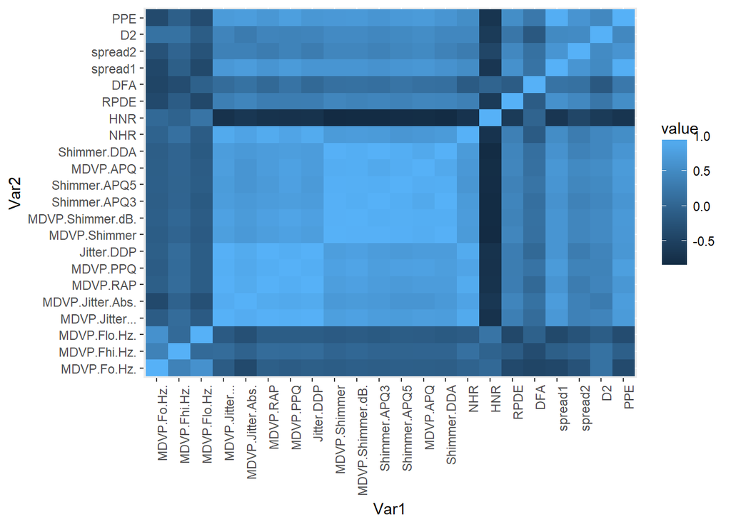

```r
ggplot(data = melted_cormat, aes(x=Var1, y=Var2, fill=value)) + geom_tile() + theme(axis.text.x = element_text(angle = 90, hjust = 1))
```

**Train/Test Split**  
Split the data 70/30 into train and test sets, using Stratified Sampling.

```r
set.seed(123)
rows=createDataPartition(PD_data$status,p = 0.7,list = F)
train <- PD_data[rows,]
test <- PD_data[-rows,]
cat("number of rows in the original data =", nrow(PD_data),"\n")
```

```
## number of rows in the original data = 195
```

```r
cat("number of rows in the train data =", nrow(train),"\n")
```

```
## number of rows in the train data = 137
```

```r
cat("number of rows in the test data =", nrow(test),"\n")
```

```
## number of rows in the test data = 58
```

## Model building

**Basic Logistic Regression Model**

Build a model using all the variables, excluding the response variable, in the dataset

```r
model_logreg_basic <- glm(status~.,family = "binomial",data = train)
summary(model_logreg_basic)
```

```
##
## Call:
## glm(formula = status ~ ., family = "binomial", data = train)
##
## Deviance Residuals:
##     Min       1Q   Median       3Q      Max
## -2.8907   0.0000   0.0111   0.1657   1.7345
##
## Coefficients:
##                    Estimate Std. Error z value Pr(>|z|)
## (Intercept)       2.748e+01  3.252e+01   0.845   0.3982
## MDVP.Fo.Hz.      -4.735e-02  3.856e-02  -1.228   0.2195
## MDVP.Fhi.Hz.      1.042e-03  5.281e-03   0.197   0.8436
## MDVP.Flo.Hz.      8.607e-03  2.586e-02   0.333   0.7393
## MDVP.Jitter...   -2.503e+03  2.085e+03  -1.200   0.2300
## MDVP.Jitter.Abs. -8.802e+04  1.460e+05  -0.603   0.5466
## MDVP.RAP         -7.697e+04  2.504e+05  -0.307   0.7585
## MDVP.PPQ         -4.853e+03  2.667e+03  -1.820   0.0688 .
## Jitter.DDP        2.820e+04  8.394e+04   0.336   0.7369
## MDVP.Shimmer     -1.249e+03  1.325e+03  -0.943   0.3457
## MDVP.Shimmer.dB.  4.349e+01  4.310e+01   1.009   0.3129
## Shimmer.APQ3     -1.947e+05  1.954e+05  -0.996   0.3192
## Shimmer.APQ5      4.734e+02  4.787e+02   0.989   0.3227
## MDVP.APQ          4.502e+02  6.000e+02   0.750   0.4531
## Shimmer.DDA       6.506e+04  6.525e+04   0.997   0.3187
## NHR               1.391e+02  7.619e+01   1.826   0.0679 .
## HNR               1.137e-01  3.266e-01   0.348   0.7278
## RPDE             -1.632e+01  9.095e+00  -1.795   0.0727 .
## DFA               2.508e+01  1.512e+01   1.658   0.0973 .
## spread1           5.028e+00  3.727e+00   1.349   0.1773
## spread2           3.331e+01  1.723e+01   1.934   0.0532 .
## D2               -1.736e+00  2.124e+00  -0.817   0.4139
## PPE               1.082e+01  4.634e+01   0.234   0.8154
## ---
## Signif. codes:  0 '***' 0.001 '**' 0.01 '*' 0.05 '.' 0.1 ' ' 1
##
## (Dispersion parameter for binomial family taken to be 1)
##
##     Null deviance: 153.528  on 136  degrees of freedom
## Residual deviance:  46.811  on 114  degrees of freedom
## AIC: 92.811
##
## Number of Fisher Scoring iterations: 9
```

```
Summary of the model shows that none of the variables is significant.
Before doing further steps we must improve the model.
One of the options is to perform the Principal Component Analysis (PCA) which will produce the independent vectors(Principal Components) which are linear combination of original features.
```

**Perform PCA and build the logistic regression model on Principal Components**

```r
pca <- prcomp(train[,-which(names(train) %in% "status")],scale. = T,center = T)
summary(pca)
```

```
## Importance of components%s:
##                           PC1    PC2     PC3    PC4     PC5     PC6    PC7
## Standard deviation     3.5235 1.5815 1.30232 1.2604 1.01752 0.88394 0.7679
## Proportion of Variance 0.5643 0.1137 0.07709 0.0722 0.04706 0.03552 0.0268
## Cumulative Proportion  0.5643 0.6780 0.75511 0.8273 0.87437 0.90989 0.9367
##                            PC8     PC9    PC10    PC11    PC12    PC13
## Standard deviation     0.63245 0.54780 0.48101 0.38925 0.34649 0.27194
## Proportion of Variance 0.01818 0.01364 0.01052 0.00689 0.00546 0.00336
## Cumulative Proportion  0.95487 0.96851 0.97903 0.98592 0.99137 0.99474
##                           PC14    PC15    PC16    PC17    PC18    PC19
## Standard deviation     0.21659 0.14991 0.14270 0.10666 0.09357 0.06990
## Proportion of Variance 0.00213 0.00102 0.00093 0.00052 0.00040 0.00022
## Cumulative Proportion  0.99687 0.99789 0.99882 0.99933 0.99973 0.99995
##                           PC20      PC21      PC22
## Standard deviation     0.03215 0.0007109 0.0001807
## Proportion of Variance 0.00005 0.0000000 0.0000000
## Cumulative Proportion  1.00000 1.0000000 1.0000000
```

```
From the summary of the PCA model, it can be seen that about 68% variation is expained by first two principal components and about 90% variation is explained by first six principal components.
```

- Plot the screeplot of the variance explained by each principal component.

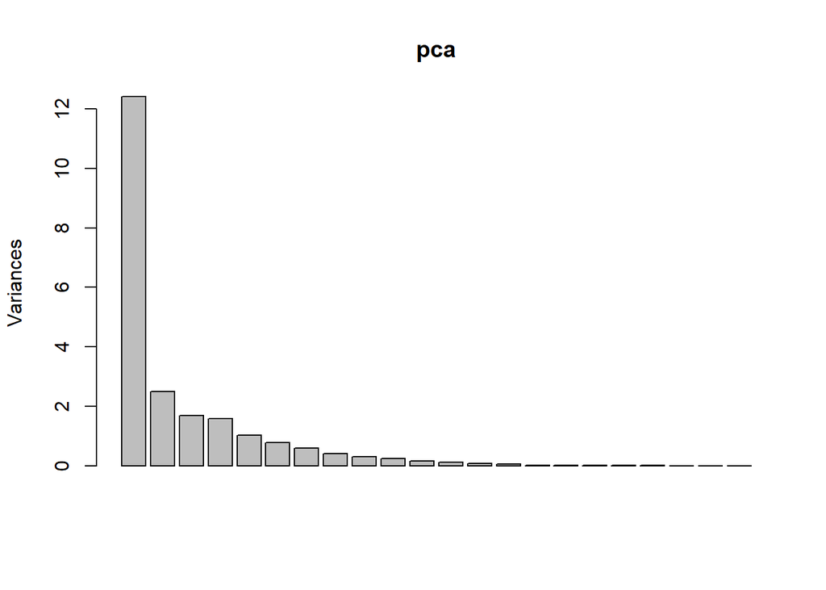

```r
screeplot(pca,type="barplot",npcs = 22)
```

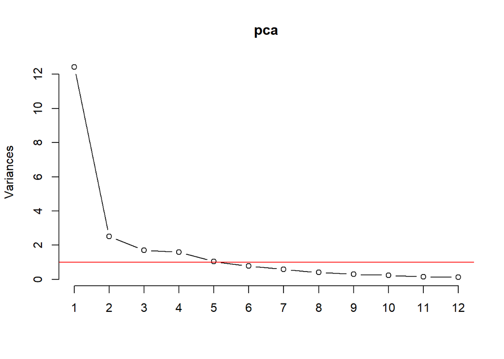

```r
screeplot(pca,type="lines",npcs = 12)
abline(h = 1,col="red")
```

**Two of the widely used approaches for selecting the number of principal components to retain:**

1. Shoulder approach Select the number of PCs to retain as the number of PCs before the shoulder.  
   According to this approch number of PCs to retain = 2
2. eigen-value-greater-than-one approch According to this approch number of PCs to retain = 5

Let us build two separate models with 2 and 5 components respectively and decide the better model by calculating different evaluation metrics.

Create the dataframes with two and five components respectively and include the response variable

```r
n1=2
n2=5
assign(paste("df_",n1,"cmp",sep = ""),data.frame(pca$x[,1:n1],status=train$status))
assign(paste("df_",n2,"cmp",sep = ""),data.frame(pca$x[,1:n2],status=train$status))
```

Build model with two and five principal components

```r
model_logreg_2cmp <- glm(status~.,data = df_2cmp,family = "binomial")
model_logreg_5cmp <- glm(status~.,data = df_5cmp,family = "binomial")

summary(model_logreg_2cmp)
```

```
##
## Call:
## glm(formula = status ~ ., family = "binomial", data = df_2cmp)
##
## Deviance Residuals:
##     Min       1Q   Median       3Q      Max
## -2.2620   0.0094   0.2930   0.5953   1.6396
##
## Coefficients:
##             Estimate Std. Error z value Pr(>|z|)
## (Intercept)   1.8135     0.3281   5.527 3.26e-08 ***
## PC1          -0.5245     0.1294  -4.053 5.06e-05 ***
## PC2          -0.5906     0.1893  -3.121   0.0018 **
## ---
## Signif. codes:  0 '***' 0.001 '**' 0.01 '*' 0.05 '.' 0.1 ' ' 1
##
## (Dispersion parameter for binomial family taken to be 1)
##
##     Null deviance: 153.53  on 136  degrees of freedom
## Residual deviance: 102.15  on 134  degrees of freedom
## AIC: 108.15
##
## Number of Fisher Scoring iterations: 6
```

```r
summary(model_logreg_5cmp)
```

```
##
## Call:
## glm(formula = status ~ ., family = "binomial", data = df_5cmp)
##
## Deviance Residuals:
##      Min        1Q    Median        3Q       Max
## -2.39407   0.00228   0.14799   0.50025   1.73192
##
## Coefficients:
##             Estimate Std. Error z value Pr(>|z|)
## (Intercept)   2.4023     0.4663   5.152 2.58e-07 ***
## PC1          -0.6815     0.1728  -3.943 8.06e-05 ***
## PC2          -0.6754     0.2248  -3.005 0.002655 **
## PC3           0.4361     0.2837   1.537 0.124254
## PC4           0.3186     0.2943   1.083 0.278999
## PC5          -1.2227     0.3608  -3.389 0.000701 ***
## ---
## Signif. codes:  0 '***' 0.001 '**' 0.01 '*' 0.05 '.' 0.1 ' ' 1
##
## (Dispersion parameter for binomial family taken to be 1)
##
##     Null deviance: 153.528  on 136  degrees of freedom
## Residual deviance:  82.366  on 131  degrees of freedom
## AIC: 94.366
##
## Number of Fisher Scoring iterations: 6
```

```
There are two insignificant components present in the model with 5 PCs.
Let us run a stepwise regression to remove insignificant components.
```

Perform the stepwise regression

```r
stepAIC(model_logreg_5cmp,direction = "both")
```

```
## Start:  AIC=94.37
## status ~ PC1 + PC2 + PC3 + PC4 + PC5
##
##        Df Deviance     AIC
## - PC4   1   83.606  93.606
## <none>      82.366  94.366
## - PC3   1   85.025  95.025
## - PC2   1   93.115 103.115
## - PC5   1   98.057 108.057
## - PC1   1  121.306 131.306
##
## Step:  AIC=93.61
## status ~ PC1 + PC2 + PC3 + PC5
##
##        Df Deviance     AIC
## - PC3   1   85.483  93.483
## <none>      83.606  93.606
## + PC4   1   82.366  94.366
## - PC2   1   94.700 102.700
## - PC5   1  100.125 108.125
## - PC1   1  123.901 131.901
##
## Step:  AIC=93.48
## status ~ PC1 + PC2 + PC5
##
##        Df Deviance     AIC
## <none>      85.483  93.483
## + PC3   1   83.606  93.606
## + PC4   1   85.025  95.025
## - PC2   1   96.799 102.799
## - PC5   1  102.147 108.147
## - PC1   1  127.361 133.361
```

```
##
## Call:  glm(formula = status ~ PC1 + PC2 + PC5, family = "binomial",
##     data = df_5cmp)
##
## Coefficients:
## (Intercept)          PC1          PC2          PC5
##      2.4714      -0.7639      -0.6446      -1.2960
##
## Degrees of Freedom: 136 Total (i.e. Null);  133 Residual
## Null Deviance:       153.5
## Residual Deviance: 85.48     AIC: 93.48
```

[output not shown]

Modified formula for model with 3 PCs

```r
model_logreg_3cmp <- glm(formula = status ~ PC1 + PC2 + PC5, family = "binomial",data = df_5cmp)
summary(model_logreg_3cmp)
```

```
##
## Call:
## glm(formula = status ~ PC1 + PC2 + PC5, family = "binomial",
##     data = df_5cmp)
##
## Deviance Residuals:
##      Min        1Q    Median        3Q       Max
## -2.39997   0.00034   0.16253   0.53866   1.72140
##
## Coefficients:
##             Estimate Std. Error z value Pr(>|z|)
## (Intercept)   2.4714     0.4679   5.282 1.28e-07 ***
## PC1          -0.7639     0.1694  -4.511 6.46e-06 ***
## PC2          -0.6446     0.2085  -3.092  0.00199 **
## PC5          -1.2960     0.3729  -3.476  0.00051 ***
## ---
## Signif. codes:  0 '***' 0.001 '**' 0.01 '*' 0.05 '.' 0.1 ' ' 1
##
## (Dispersion parameter for binomial family taken to be 1)
##
##     Null deviance: 153.528  on 136  degrees of freedom
## Residual deviance:  85.483  on 133  degrees of freedom
## AIC: 93.483
##
## Number of Fisher Scoring iterations: 6
```

The output is probability of success. Now we need to decide a threshold for it.

Check for the Area Under Curve (AUC) value for ROC curve.

```r
pred_status_2cmp <- predict(model_logreg_2cmp,df_2cmp[,-3],type="response")
pred_status_3cmp <- predict(model_logreg_3cmp,df_5cmp[,-c(3,4)],type="response")

pred2 <- ROCR::prediction(predictions = pred_status_2cmp,labels = train$status)
pred3 <- ROCR::prediction(predictions = pred_status_3cmp,labels = train$status)

perf_auc2 <- performance(pred2, measure="auc")
perf_auc3 <- performance(pred3, measure="auc")

# Access the auc score from the performance object
auc2 <- perf_auc2@y.values[[1]]
auc3 <- perf_auc3@y.values[[1]]
print(auc2)
```

```
## [1] 0.8569389
```

```r
print(auc3)
```

```
## [1] 0.9074814
```

```
The value of AUC is decently large for both the models.
Model with 3 principal components has slightly higher AUC
```

Let us plot the the ROC curve for both the models and decide the threshhold limits.

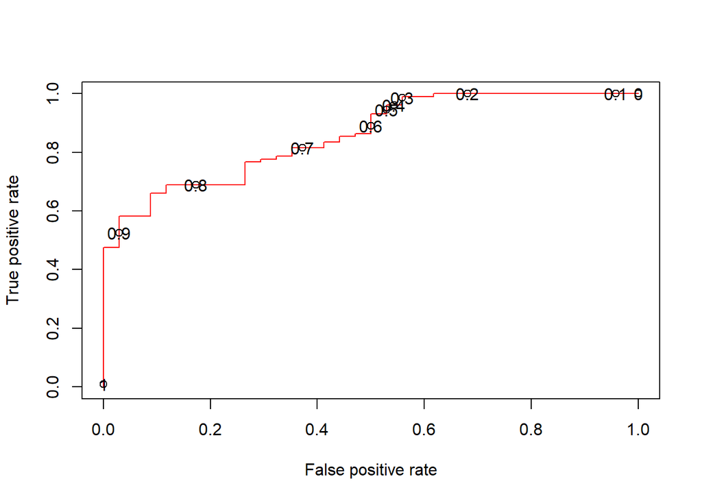

```r
perf2 <- ROCR::performance(pred2,measure = "tpr",x.measure = "fpr")
perf3 <- ROCR::performance(pred3,measure = "tpr",x.measure = "fpr")

plot(perf2,col=rainbow(10),colorsize=T,print.cutoffs.at=seq(0,1,0.1))
```

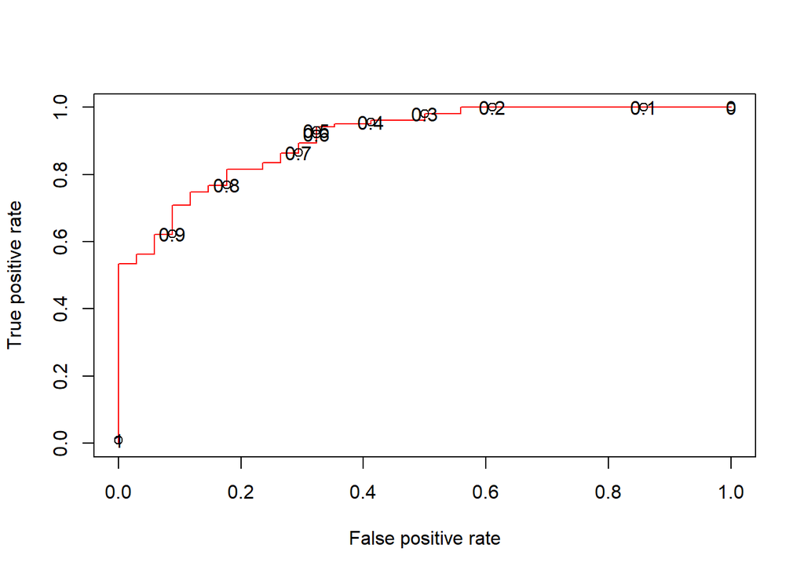

```r
plot(perf3,col=rainbow(10),colorsize=T,print.cutoffs.at=seq(0,1,0.1))
```

**From the TPR vs FPR plot, it is wise to select p = 0.8 as threshold**

Generate the projections using the first two principal components using biplot

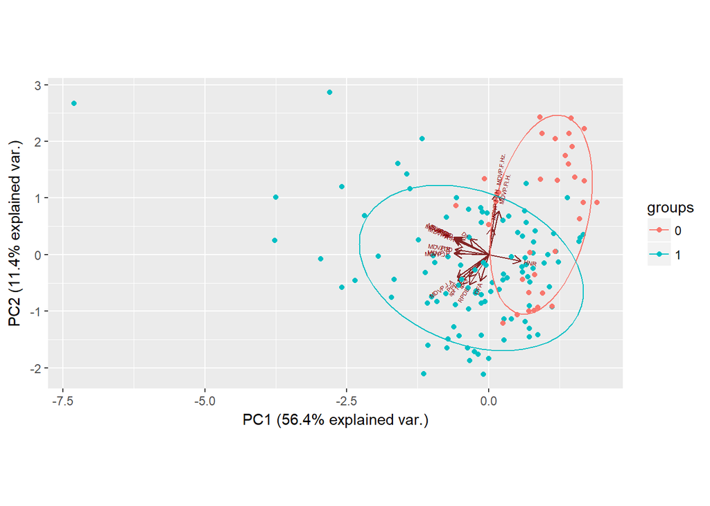

```r
ggbiplot::ggbiplot(pca,groups = train$status,obs.scale = 0.2,var.scale = 0.2,ellipse = T,circle = F,varname.size = 1.5,varname.abbrev = T)
```

## PREDICTION

Now that we got the threshold probabilities for sucess. Make predictions on test data

Perform the PCA on the test data

```r
test_pca2 <- data.frame(predict(pca,newdata=test))[,1:2]
test_pca3 <- data.frame(predict(pca,newdata=test))[,c(1,2,5)]
```

Make predictions on the test data

```r
pred_test_prob2 <- predict(model_logreg_2cmp,test_pca2,type = "response")
pred_test2 <- ifelse(pred_test_prob2 <= 0.8,0,1)
pred_test_prob3 <- predict(model_logreg_3cmp,test_pca3,type = "response")
pred_test3 <- ifelse(pred_test_prob3 <= 0.8,0,1)
```

Construct the confusion matrices

```r
caret::confusionMatrix(pred_test2,test$status,positive="1")
```

```
## Confusion Matrix and Statistics
##
##           Reference
## Prediction  0  1
##          0 14 12
##          1  0 32
##
##                Accuracy : 0.7931
##                  95% CI : (0.6665, 0.8883)
##     No Information Rate : 0.7586
##     P-Value [Acc > NIR] : 0.330549
##
##                   Kappa : 0.5628
##  Mcnemar's Test P-Value : 0.001496
##
##             Sensitivity : 0.7273
##             Specificity : 1.0000
##          Pos Pred Value : 1.0000
##          Neg Pred Value : 0.5385
##              Prevalence : 0.7586
##          Detection Rate : 0.5517
##    Detection Prevalence : 0.5517
##       Balanced Accuracy : 0.8636
##
##        'Positive' Class : 1
##
```

```r
caret::confusionMatrix(pred_test3,test$status,positive="1")
```

```
## Confusion Matrix and Statistics
##
##           Reference
## Prediction  0  1
##          0  9 11
##          1  5 33
##
##                Accuracy : 0.7241
##                  95% CI : (0.591, 0.8334)
##     No Information Rate : 0.7586
##     P-Value [Acc > NIR] : 0.7817
##
##                   Kappa : 0.3428
##  Mcnemar's Test P-Value : 0.2113
##
##             Sensitivity : 0.7500
##             Specificity : 0.6429
##          Pos Pred Value : 0.8684
##          Neg Pred Value : 0.4500
##              Prevalence : 0.7586
##          Detection Rate : 0.5690
##    Detection Prevalence : 0.6552
##       Balanced Accuracy : 0.6964
##
##        'Positive' Class : 1
##
```

[output not shown]